# Exploratory analysis of the RAND Health Insurance Experiment (HIE) data

EB

2023-04-11

## Introduction

The RAND Health Insurance Experiment (HIE), which ran from 1974 to 1982, was one of the most influential social experiments in research history. It’s purpose was to evaluate the price elasticity of the health insurance plans. The HIE enrolled 3,958 people aged 14 to 61 from six areas of the USA. The results of this randomized experiment could be used for evaluating the causal effect of the health insurance on peoples health.

Data that we are using is greater details is described in the Chapter 1. Randomized Trials in [Angrist, J. D., & Pischke, J.-S. (2014). Mastering’metrics: The path from cause to effect. Princeton University Press.](https://hds.hebis.de/ubgi/Record/HEB35797798X). For our exercise, we use a somehow simplified data set with only two distinct insurance plans:

1. Catastrophic - Analogy of having no insurance
2. Free - the most comprehensive insurance plan that allows practically any medical treatment for free.

The question that we want to answer is about the causal effect of insurance of enrolled people health. However, such question is for later in this course. For now, we only want to learn how to make basic data visualization and summary statistics and perform means comparison t-test in R.

## Loading packages and the data

To start working in R, we need to load packages. Sometimes, when we have a fresh new version of R, we need to install libraries before loading them. To install package, one need to run: `install.packages("name_of_the_package")`.

```r
# install.package("psych")
library(psych)
# install.package("tidyverse")
library(tidyverse)
```

Loading data.

```r
pre_dta <- read_csv("rand-hie-pre-treatment.csv")
```

Inspect the data:

```r
glimpse(pre_dta)
```

```
## Rows: 2,054
## Columns: 13
## $ id                   <chr> "KA100082", "KA100082", "KA100082", "KA100082", "…
## $ plantype             <dbl> 4, 4, 4, 4, 1, 1, 1, 1, 1, 1, 1, 4, 4, 1, 1, 4, 4…
## $ female               <dbl> 0, 0, 1, 1, 1, 1, 1, 0, 0, 0, 1, 1, 0, 1, 0, 0, 0…
## $ non_white            <dbl> 1, NA, NA, 1, NA, 1, NA, 1, NA, 1, 1, 1, 1, 0, 0,…
## $ age                  <dbl> 42, 16, 14, 43, 15, 60, 14, 59, 14, 45, 37, 55, 5…
## $ education_years      <dbl> 12, NA, NA, 12, NA, 9, NA, 4, NA, 7, 12, 11, 7, 1…
## $ income_family        <dbl> 67486.48, 67486.48, 67486.48, 67486.48, 24540.54,…
## $ hospitalization      <dbl> 0, 0, 0, 0, 0, 0, 0, 0, 1, 0, 0, 0, 0, 0, 1, 0, 0…
## $ general_health_index <dbl> NA, NA, NA, NA, NA, NA, NA, NA, NA, NA, NA, NA, N…
## $ cholesterol          <dbl> NA, NA, NA, NA, NA, 247, NA, 185, 230, 210, 295, …
## $ blood_pressure       <dbl> NA, NA, NA, NA, NA, 130, NA, 136, 98, 134, 110, N…
## $ mental_health_index  <dbl> 95.0, 93.8, 98.7, 96.3, 61.1, 71.6, 63.5, 71.6, 9…
## $ plan                 <chr> "Catastrophic", "Catastrophic", "Catastrophic", "…
```

Answer the questions:

- How many observations are in the data?
- What is/are the variable(s) that indicate type of the insurance coverage?
- What insurance coverage is an insurance and what coverage is as no-insurance?
- What does NA values stand for in some variables?

### Counting number of observations

To count number of observations in each coverage

```r
pre_dta %>% count(plan)
```

```
## # A tibble: 2 × 2
##   plan             n
##   <chr>        <int>
## 1 Catastrophic   759
## 2 Free          1295
```

Count number of observations in each coverage and by sex

```r
pre_dta %>% count(plan, female)
```

```
## # A tibble: 4 × 3
##   plan         female     n
##   <chr>         <dbl> <int>
## 1 Catastrophic      0   334
## 2 Catastrophic      1   425
## 3 Free              0   619
## 4 Free              1   676
```

Count number of observations in each coverage and by the `non_white` variable.

```r
# Write your code here
pre_dta %>% count(plan, non_white)
```

```
## # A tibble: 6 × 3
##   plan         non_white     n
##   <chr>            <dbl> <int>
## 1 Catastrophic         0   497
## 2 Catastrophic         1   103
## 3 Catastrophic        NA   159
## 4 Free                 0   847
## 5 Free                 1   142
## 6 Free                NA   306
```

Answer:

- What does `NA` in the `non_white` column stands for?

## Summary statistics

```r
describe(pre_dta)
```

```
##                      vars    n     mean       sd  median  trimmed      mad  min
## id*                     1 2054   511.70   299.69   512.5   513.48   393.63  1.0
## plantype                2 2054     2.11     1.45     1.0     2.01     0.00  1.0
## female                  3 2054     0.54     0.50     1.0     0.55     0.00  0.0
## non_white               4 1589     0.15     0.36     0.0     0.07     0.00  0.0
## age                     5 2053    32.64    13.29    30.0    31.83    14.83 14.0
## education_years         6 1784    11.94     3.04    12.0    12.00     2.97  0.0
## income_family           7 1945 30986.38 17557.40 29876.7 30197.23 18825.46  0.0
## hospitalization         8 2035     0.12     0.32     0.0     0.02     0.00  0.0
## general_health_index    9 1564    70.00    15.00    71.6    70.80    15.12  5.7
## cholesterol            10 1198   203.93    42.80   200.0   201.41    41.51 51.0
## blood_pressure         11 1215   123.07    16.34   122.0   122.19    14.83 82.0
## mental_health_index    12 1967    74.41    14.03    77.1    75.60    12.60 12.2
## plan*                  13 2054     1.63     0.48     2.0     1.66     0.00  1.0
##                           max    range  skew kurtosis     se
## id*                   1007.00  1006.00 -0.04    -1.26   6.61
## plantype                 4.00     3.00  0.54    -1.71   0.03
## female                   1.00     1.00 -0.14    -1.98   0.01
## non_white                1.00     1.00  1.91     1.66   0.01
## age                     62.00    48.00  0.44    -0.91   0.29
## education_years         25.00    25.00 -0.15     1.11   0.07
## income_family        89132.16 89132.16  0.38    -0.43 398.11
## hospitalization          1.00     1.00  2.40     3.75   0.01
## general_health_index   100.00    94.30 -0.59     0.44   0.38
## cholesterol            380.00   329.00  0.58     0.55   1.24
## blood_pressure         230.00   148.00  0.75     2.09   0.47
## mental_health_index    100.00    87.80 -0.87     0.81   0.32
## plan*                    2.00     1.00 -0.54    -1.71   0.01
```

## Checks and balances

The goal of the checks and balances is to understand if the groups compared are truly random. Groups are considered well assigned randomly, when there is no statistically significant difference between them. We can check the differences between groups visually (using box plot) or using statistical test (t-test).

### Age

Answer, are there any difference in the mean age?

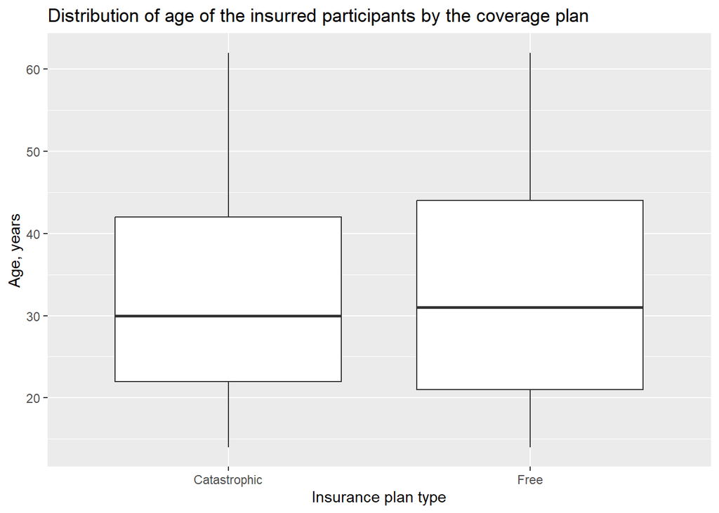

```r
pre_dta %>%
  ggplot() +
  aes(x = plan, y = age) +
  geom_boxplot() +
  xlab("Insurance plan type") +
  ylab("Age, years") +
  labs(title = "Distribution of age of the insurred participants by the coverage plan")
```

We can also perform a statistical test (t-test) to identify presence of any statistically significant difference between two groups.

Based on the test below, conclude, what is the difference between means of two groups.

```r
t.test(age ~ plan, data = pre_dta)
```

```
##
##  Welch Two Sample t-test
##
## data:  age by plan
## t = -0.72398, df = 1644.5, p-value = 0.4692
## alternative hypothesis: true difference in means between group Catastrophic and group Free is not equal to 0
## 95 percent confidence interval:
##  -1.6134304  0.7434701
## sample estimates:
## mean in group Catastrophic         mean in group Free
##                   32.36100                   32.79598
```

### Education years

- What variable corresponds to the education level?
- Make the box plot for education level by insurance.
- Perfume a t-test for means difference in education between insurance plans.
- Conclude whether there is a significant difference between education of the covered and not covered people.